# model builder וסיכום הקורס

ד"ר עדו קליין

04/11/2021

# מה זה מודל בילדר

כלי שמאפשר תיעוד ואוטומציה של עבודה

# הדגמה

מודל שהכנתי כדי להתאמן, במיוחד עבורכם

# כל כלי הוא בעצם קריאה לפונקציה

כשאני לוקח שכבה ומכניס אותה כפלט, השכבה היא למשעה פרמטר שמזינים לפונקציה. למשל בבאפר - יש לי שכבת קלט, מרחק של הבאפר, וכו’. כל אחד מהפרמטרים האלה הוא משתנה שאני צריך לספק לפונקציה.

[figure not shown]

# מודל בילדר - דרך לחבר בין קלטים ופלטים

# בואו נכיר את החלון

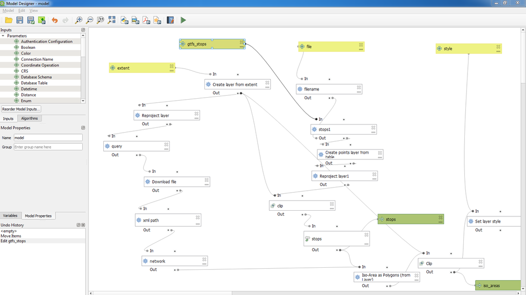

סרגל הכלים מאוד אינטואיטיבי ופחות חשוב

קלטים - דרך להגדיר משתנה

אלגורתמים

משתנים (פחות חשוב)

הגדרות מודל

היסטורית עריכות

תאור גרפי של המודל

# טיפ ראשוני - שיימו את המודל שלכם

אחרת לא תוכלו לשמור אותו כקובץ.

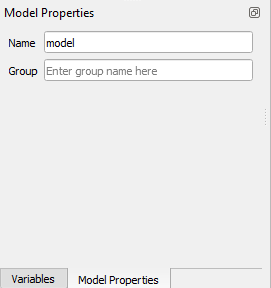

# משתנים/קלטים ראשוניים

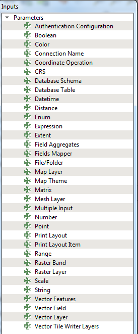

יש הרבה מאוד קלטים שאפשר להכניס. לא כולם רלוונטיים. מה שכן, בוודאות גבוהה - vector layer, number, string

הוספת המשתנה על ידי דאבל קליק או גרירה לתוך האזור הגרפי

[figure not shown]

שיום המשתנה - בdescription. חשוב מאוד כדי לא להתבלבל.

# אלגורתמים

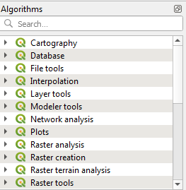

מאוד דומה לprocessing toolbox, ולעיתים מכיל אפילו יותר כלים, למשל של תוספים.

למעשה מקום לבחור ממנו את האלגוריתם בו נרצה להשתמש, דאבל קליק או גרירה לאזור הגרפי

[figure not shown]

שוב, חשוב מאוד לשיים כדי לא להתבלבל בdescription

# ארבעה סוגים של קלטים

### ערך

מאפשר להוסיף ערך מהסוג של השדה, הנמצא זמין - או ערך דיפולטיבי

### ממנוע הביטויים

דיברנו על מנוע הביטויים בשיעורים קודמים. מאפשר ערכים שנמצאים בסביבה של הפרויקט למשל.

### משתנה שהגדרנו בהתחלה

### פלט של תהליך קודם

במידה ויש לנו תוצאה של אלגורתם, אפשר לחבר אותו לאלגוריתם הנוכחי (במידה והוא מסוג מתאים)

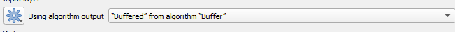

שימו לב - לפעמים לאלגוריתם יש מספר פלטים, יש לבחור את הפלט הנכון.

# פלטים

מאפשר שמירה של תוצר הביניים והצגתו כתוצאת האלגורתם. טוב לבדיקה האם האלגוריתם שלנו עובד כשורה.

# היסטוריה

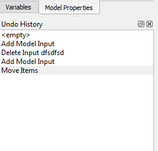

כל עריכות המודל נמצאות בחלונית הזאת. ניתן לחזור למצב קודם .

# איך נשמור מודלים

אפשר לשמור את המודלים לקובץ חיצוני עם סיומת .model3

לא מומלץ, תמיד כדאי לעבוד בתוך פרויקט. ניתן לשמור מודלים לתוך פרויקט, ואז גם נראה אותם בproccessing toolbox

[figure not shown]

# תיעוד

חשוב מאוד! רק לפעמים אין כוח או שוכחים

[figure not shown]

# תרגיל:

באמצעות שכבת קווי הרק"ל ותחנות הרקל, יצרו כלי שמוצא את ה100 מטרים הקרובים של קו רקל מכל תחנת רקל.

# סיכום הקורס

למדנו על:

עבדוה עם gpkg

סימבולוגיה

עבודה עם דאטה מרחבי

עריכה טבלאית ומרחבית

סרויסים ומקורות מידע תחבורתיים

qneat

מודל בילדר

יש שאלות?